# 01.01.00.00.ProblemaNCuerpos.SolucionNumerica

Indice | Previo: ProblemaNCuerpos |

## 1.1. Solución numérica

Por mucho tiempo, desde su formulación su formulación implícita en los *Principia* en 1687, hasta su formulación oficial en 1889 para el concurso del Rey Oscar, la solución al problema de los N cuerpos para cualquier valor de N (seolución global) escapó a matemáticos, físicos y astrónomos.

Como mencionamos en *Historias de la Mecánica Celeste* en Formulación del problema de los N cuerpos, la existencia de una solución para el caso N=3 fue demostrada definitivamente por F. K. Sundman en 1913, después del primer intento (parcialmente fallido) por Poincaré en 1889.

En 1991, el matemático américano de origen chino, Wang Qui-Dong Qiu-Dong, 1990, demostró que incluso para el caso de N>3 existe una solución global al problema, al menos cuando el momento angular total del sistema es cero (volveremos sobre el momento angular en el sistema de N cuerpos en Integrales de movimiento)

En ninguno de los dos trabajos mencionados (el de Sundman o el de Qui-Dong), sin embargo, las series necesarias para calcular la posición futura de los cuerpos en sistemas de N cuerpos, fueron provistas explícitamente. Los trabajos demostraron la existencia de la solución, sin presentar formas explícitas de ella. Gran parte de este libro, y en general de la Mecánica Celeste como disciplina científica, consiste justamente en la búsqueda de soluciones específicas al problema o al menos de pistas físicas que nos permitan conocer la evolución futura de sistemas de pocas o muchas partículas. Solo de esta manera, el problema de los N cuerpos tiene un valor práctico en astronomía.

Hoy por hoy, la aproximación más utilizada para la solución del problema de los N cuerpos es la que se vale de algoritmos numéricos, implementados como programas de computadora que corren en poderosos ordenadores. En las próximas secciones exploraremos los fundamentos de esta aproximación a la solución del problema.

Si bien se podría pensar que, en el presente, la solución numérica agota el problema y no hace falta ninguna exploración teórica adicional, nada esta más lejos de la realidad. La búsqueda de formalismos analíticos que permitan describir sistema con dos, tres o más cuerpos, o al menos conseguir información sobre ellos, ha sido un problema central en mecánica celeste, incluso hoy cuando los computadores parecen ofrecernos soluciones muy precisas al problema.

Si abordamos la solución numérica desde temprano en este texto es porque ella nos permitirá poner a prueba soluciones analíticas, conjeturas e intuiciones teóricas que presentaremos en lo que resta del texto. Adicionalmente, las herramientas algorítmicas desarrolladas en estas secciones nos servirán más adelante para estudiar y visualizar problemas mejor conocidos.

### 1.1.1. Unidades canónicas

La fuerza gravitacional es la fuerza más débil del Universo. Por esta razón el valor de la constante que determina su intensidad $G$ es muy pequeño. Al menos en las unidades que hemos definido en la vida cotidiana para medir los patrones de longitud, tiempo y masa. En el Sistema Internacional $G\sim 10^{-10}$ (en lo sucesivo $\sim$ no se usará para indicar el valor aproximado de una cantidad, sino *orden de magnitud*.)

De otro lado, en Astronomía, las cantidades involucradas en el cálculo de la fuerza gravitacional (Ecuación fundamentos_mecanica_gravedad), es decir, las masas de los cuerpos $m_j$ y sus distancias mutuas $r_{ij}$, tienen valores enormes en esas mismas unidades. Así por ejemplo en el sistema Tierra-Sol, $m\sim 10^{24}-10^{30}$ kg y $r\sim 10^{11}$ m.

Con el propósito de evitar la combinación de cantidades muy grandes y muy pequeñas en las mismas ecuaciones, se ha convenido en utilizar un sistema de unidades en el cuál todas las cantidades implicadas tengan, por un lado, una magnitud similar y por el otro sus valores sean de orden uno.

Las dimensiones o unidades de la constante de gravitación universal $G$ son:

$$ [G] = \frac{L^3}{M T^2}, $$

es decir, en esta constante están combinados los patrones usados para definir todas las cantidades físicas relevantes en problemas mecánicos. Si ajustamos el valor de estas tres unidades fundamentales, podemos obtener casi cualquier valor que deseemos para $G$.

Supongamos, por ejemplo, que definimos un sistema de unidades nuevo, ${\cal L}$, ${\cal M}$, ${\cal T}$ (que denotan la unidad de longitud, masa y tiempo respectivamente), para el cual, en unidades del SI, los factores de conversión son iguales a $U_L$, $U_M$ y $U_T$ respectivamente. Esto es, para convertir, por ejemplo, de una distancia medida en $\cal L$ a la misma distancia en $m$ (metros) sería necesario multiplicar por $U_L$.

Así por ejemplo, en astronomía podríamos escoger medir las longitudes (y todas las cantidades derivadas) en *Unidades Astronómicas* (UA o AU, por sus siglas en inglés), en lugar de hacerlo en metros. Como sabemos que 1 AU $=1.496\times 10^{8}$ km $=1.496\times 10^{11}$ m, entonces en este sistema de unidades, ${\cal L}={\rm AU}$ y $U_L=1.496\times 10^{11}$ m. Así mismo, podríamos escoger medir la masa en unidades de la masa del sol $M_\odot$ (como se acostumbra hacerlo por ejemplo en astronomía estrelar). En este caso ${\cal M}=M_\odot$, $U_M=1.98\times 10^{30}$ kg

El propósito original de las unidades canónicas en mecánica celeste es conseguir que, en este nuevo sistema de unidades, el valor de la constante de gravitación universal sea pequeño y de orden 1. Dada la arbitrariedad de nuestra elección, podemos ir más lejos e imponer la condición de que la constante tenga un valor exactamente igual a 1 (los cálculos en los que aparezca la constante se simplificarán considerablemente).

En el sistema definido en el ejemplo antes, si escogemos una unidad de tiempo $\cal T$ tal que $U_T=5033865$ segundos (ver justificación abajo), el valor de la constante de gravitación será:

Como vemos en este nuevo sistema de unidades el valor de la constante gravitacional es exactamente igual a 1, lo que simplificará considerablemente los cálculos en los que aparezca esta cantidad. Decimos que AU, $M_\odot$, $\cal T$ forman un conjunto de unidades canónicas.

**Definición 1.1. Unidades canónicas.** A un conjunto de unidades $\cal L, M, T$ con factores de conversión $U_L, U_M, U_T$ se los llama *unidades canónicas* en mecánica celeste, si se cumple que:

o equivalentemente:

Donde $G = 6.67308\times 10^{-11} {\rm m}^3 {\rm kg}^{-1}{\rm s}^{-2}$.

En la práctica, en la Ec. (definicion_unidades_canonicas), si fijamos el valor de dos de los factores de conversión, podemos encontrar el valor del tercer factor.

En el ejemplo anterior, si fijamos $U_L=1.496\times 10^{11}$ m y $U_M=1.98\times 10^{30}$ kg, entonces

$$ U_T = \sqrt{\frac{U_L^3}{G U_M}}. $$

Numéricamente:

```python
G=6.67308e-11
UL=1.496e11
UM=1.98e30

UT=(UL**3/(G*UM))**0.5
```

```
UT = 5033865.755208481 segundos
   = 1398.296043113467 horas
   = 58.26233512972779 días
   = 0.15951080126450734 años
```

En física decimos que la **escala de tiempo** característica de la dinámica sistema Tierra-Sol (que podríamos considerar similar al período orbital de la Tierra) se puede estimar combinando apropiadamente la constante de gravitación universal (intensidad de la interacción) con la masa del sistema y la separación característica de los cuerpos que lo constituyen.

A partir del sistema de unidades canónicas introducidas, es posible definir los patrones de medida para todas las restantes cantidades mecánicas:

```python
UV=UL/UT
UP=UM*UV
UH=UM*UL*UP
UA=UL/UT**2
UE=UM*UL**2/UT**2
```

```
    Velocidad, UV = 29718.710683774327 m/s
    Aceleración, UA = 0.005903755111670335 m/s^2
    Momentum lineal, UP = 5.884304715387317e+34 kg m/s
    Momentum angular, UH = 1.7429781311354465e+76 kg m^2/s
    Energía, UE = 1.7487394941176467e+39 kg m^2/s^2
```

De nuevo, como sucede con la unidad de tiempo, estas unidades no son solo el producto de operaciones aritméticas entre cantidades "arbitrarias". Sus valores nos dan una idea de las escalas (valores típicos) de cada cantidad en el sistema.

**Historias de la mecánica celeste: Unidades canónicas.** La motivación presentada aquí para la introducción de las unidades canónicas no es la misma que la que se esboza en textos clásicos de la disciplina. En realidad en distintos tiempos, han sido otras las razones para usar un sistema de unidades propio en mecánica celeste.

.

Después de la segunda guerra mundial durante la que se desarrollaron los primeros misiles balísticos de largo alcance (los temidos V2), quedo claro que los humanos podríamos alcanzar el espacio y viajar por nuestro sistema planetario. Para navegar el Sistema Solar, sin embargo, era necesario conocer muy bien las masas y distancias relativas de los grandes cuerpos astronómicos que dominarían la dinámica de esos vehículos espaciales. Para la época, sin embargo (incluso para 1971, cuando fue escrito el texto de Bate y compañía) el valor de la distancia Tierra-Sol y la masa de nuestra estrella, no eran conocidas con gran precisión. Este hecho motivo a muchos a resolver los primeros problemas de mecánica celeste práctica, asignando a estas cantidades desconocidas un valor de 1 (unidades de masa y distancia) y calculando todas las propiedades relevantes del problema en términos de ellas. Este fue el origen del uso de unidades canónicas, al menos en el contexto de la mecánica orbital de finales del siglo xx.

### 1.1.2. Las ecuaciones de movimiento de primer orden

En unidades canónica, las ecuaciónes de movimiento del sistema de N cuerpos se escriben de la misma manera que en la Ec. (ncuerpos_ecuaciones):

\begin{equation} \label{eq:ncuerpos_numerico_ecuaciones} \left\{\ddot{\vec r}_i= -\sum_{j\neq i} \frac{\mu_j}{r_{ij}^3} \vec{r}_{ij} \right\}_{N} \end{equation}

La diferencia es que ahora $\mu_j=m_j$.

**Nota: Unidades del parámetro gravitacional.** El hecho de que en unidades canónicas el valor numérico del parámetro gravitacional de un cuerpo $\mu=Gm$ coincida con la masa $m$, no debe llevar a confundir las dos cantidades físicas. No debemos perder de vista que las unidades de $\mu$ son $L^3/T^2$, mientras que la de $m$ es, por definición, $M$. En la igualdad anterior, entonces, se ha oscurecida el efecto que tiene la constante gravitacional en el equilibrio dimensional de esta igualdad.

El problema de los N cuerpos es entonces descrito por un conjunto de ecuaciones diferenciales (vectoriales) no lineales (que incluye factores con potencias distintas de uno de las funciones) y de segundo orden (que van hasta las segundas derivadas de las mismas).

¿Cuántas ecuaciones diferenciale tenemos que resolver? Reconociendo la naturaleza vectorial de las funciones relevantes, $\vec r_i(t):[x_i(t),y_i(t),z_i(t)]$, $\dot{\vec r}_i(t):[{\dot x}_i(t),{\dot y}_i(t),{\dot z}_i(t)]$, es claro que es necesario resolver $3N$ ecuaciones diferenciales de segundo orden (una para ${\dot x}_i(t)$, otra para ${\dot y}_i(t)$ y así sucesivamente).

Con el propósito de resolver numéricamente este sistema de ecuaciones diferenciales, usando los métodos y herramientas que introdujimos en Fundamentos de Mecánica, Cinemática, es necesario convertir estas *reducir* el orden de estas ecuaciones diferenciales, es decir convertirlas en un sistema equivalente de ecuaciones de primer orden.

Para ello, primero debemos introducir las funciones auxiliares $Y_i(t)$ que identificaremos con las funciones relevantes en el problema $x_i(t),y_i(t),z_i(t),{\dot x}_i(t),{\dot y}_i(t),{\dot z}_i(t)$.

Una elección *posible* de esta identificación puede ser la siguiente:

$$ \begin{array}{ccc} Y_0 = x_{0}, & Y_1 = y_{0}, & Y_2 = z_{0}\\ Y_3 = x_{1}, & Y_4 = y_{1}, & Y_5 = z_{1}\\ & \ldots & \\ Y_{3N+0} = {\dot x}_{0}, & Y_{3N+1} = {\dot y}_{0}, & Y_{3N+2} ={\dot z}_{0}\\ Y_{3N+3} = {\dot x}_{1}, & Y_{3N+4} = {\dot y}_{1}, & Y_{3N+5} ={\dot z}_{1}\\ & \ldots & \\ \end{array} $$

O, en general:

\begin{equation} \label{eq:numerico_variables_auxiliares} \begin{array}{ccc} Y_{3i} = x_{i}, & Y_{3i+1} = y_{i}, & Y_{3i+2} = z_{i}\\ Y_{3N+i} = {\dot x}_{i}, & Y_{3N+i+1} = {\dot y}_{i}, & Y_{3N+i+2} ={\dot z}_{i} \end{array} \end{equation}

Con esta identificación, se hace claro que para $k<3N$ (componentes de la posición), ${\dot Y}_{k}=Y_{3N+k}$.

Más difícil, sin embargo, es encontrar una fórmula general para ${\dot Y}_k$ para $k\geq 3N$ (derivadas de las componentes de la velocidad o componentes de la aceleración).

Sabemos que para la partícula $i$, la Ec. (ncuerpos_numerico_ecuaciones) se puede escribir como:

$$ \begin{array}{lll} \ddot{x}_i & = & -\sum_{j\neq i} \mu_j (x_i-x_j) / r_{ij}^3 \\ \ddot{y}_i & = & -\sum_{j\neq i} \mu_j (y_i-y_j) / r_{ij}^3 \\ \ddot{z}_i & = & -\sum_{j\neq i} \mu_j (z_i-z_j) / r_{ij}^3 \\ \end{array} $$

Con $r_{ij}=\sqrt{(x_i-x_j)^2+(y_i-y_j)^2+(z_i-z_j)^2}$.

En términos de las funciones auxiliares, se puede escribir:

$$ \begin{array}{lll} \dot{Y}_{3N+i} & = & -\sum_{j\neq i} \mu_j (Y_{3i}-Y_{3j}) / r_{ij}^3 \\ \dot{Y}_{3N+i+1} & = & -\sum_{j\neq i} \mu_j (Y_{3i+1}-Y_{3j+1}) / r_{ij}^3 \\ \dot{Y}_{3N+i+2} & = & -\sum_{j\neq i} \mu_j (Y_{3i+2}-Y_{3j+2}) / r_{ij}^3 \\ \end{array} $$

Con

\begin{equation} \label{eq:ncuerpos_definicion_rij} r_{ij}=\sqrt{(Y_{3i}-Y_{3j})^2+(Y_{3i+1}-Y_{3j+1})^2+(Y_{3i+2}-Y_{3j+2})^2} \end{equation}

En general entonces, para $k\geq 3N$ las ecuaciones de movimiento en términos de las funciones auxiliares se pueden escribir como:

$$ \dot{Y}_k = -\sum_{j\neq i} \mu_j (Y_{3i+l}-Y_{3j+l}) / r_{ij}^3 $$

Donde $l=k\;{\rm mod}\;3$ (residuo de la división de $k$ entre 3) e $i=\lfloor (k-3N)/3\rfloor$ (valor entero más pequeño que el número resultante de dividir $k-3N$ por 3).

Con la asignación anterior, el conjunto de $3N$ ecuaciones diferenciales escalares de segundo orden que describe la dinámica de un sistema de N cuerpos, se convierte en el conjunto *reducido* de $6N$ ecuaciones diferenciales de primer orden (en las variables auxiliares) escrito a continuación:

\begin{equation} \label{eq:ncuerpos_ecuaciones_reducidas} \dot Y_k = \left\{ \begin{array}{ccc} Y_{3N+k} & {\rm ,} & 0 \leq k < 3N \\ -\sum_{j\neq i} \mu_j (Y_{3i+l}-Y_{3j+l}) / r_{ij}^3 & {\rm ,} & 3N\leq k < 6N \end{array} \right. \end{equation}

Donde $l=k\;{\rm mod}\;3$ e $i=\lfloor (k-3N)/3\rfloor$ y $r_{ij}$ esta definido por Ec. (numerico_definicion_rij).

En lo sucesivo llamaremos a este conjunto de ecuaciones diferenciales, las **ecuaciones de primer orden reducidas** o simplemente **ecuaciones reducidas** del problema de los N cuerpos.

### 1.1.3. Algoritmo de solucion

Para resolver numéricamente las ecuaciones reducidas de los N cuerpos debemos preparar una rutina que implemente la Ec. (ncuerpos_ecuaciones_reducidas). El diseño de la rutina es similar al que hicimos con otras ecuaciones de movimiento, en Fundamentos de Mecánica, Cinemática. Esta rutina, que utilizaremos frecuentemente en lo queda de este texto, se presenta abajo. Aségurese de entender la manera como cada uno de los detalles de la Ec. (ncuerpos_ecuaciones_reducidas) son expresados en el lenguaje de programación elegido.

```python
def eom_ncuerpos(Y,t,N,mus):
    import numpy as np
    dYdt=np.zeros(6*N)

    #Primer conjunto de ecuaciones
    dYdt[:3*N]=Y[3*N:]

    #Segundo conjunto de ecuaciones
    for k in range(3*N,6*N):
        l=k%3
        i=int(np.floor((k-3*N)/3))
        for j in range(N):
            if j==i:continue
            rij=(Y[3*i]-Y[3*j])**2+\
                (Y[3*i+1]-Y[3*j+1])**2+\
                (Y[3*i+2]-Y[3*j+2])**2
            dYdt[k]+=-mus[j]*(Y[3*i+l]-Y[3*j+l])/rij**1.5

    return dYdt
```

Para ilustrar como puede se usa esta, supongamos que queremos predecir la posición en $t=1$ (en unidades canónicas) de las partículas que conforman el sistema mostrado en la Figura (ncuerpos_numerico_ejemplo).

[figure not shown]

**Figura 1.1**. Sistema de tres cuerpos de ejemplo (todas las cantidades están expresadas en unidades canónicas)::t

Las propiedades del sistema (masas y número de partículas) y las condiciones iniciales indicadas en la Figura, pueden expresarse, en términos de las variables auxiliares $\{Y_k\}$, de la siguiente manera:

```python
N=3
mus=[1,0.2,0.5]
Yo=[
    #Posición cuerpo 0
    0,0,0,
    #Posición cuerpo 1
    1,0,0,
    #Posición cuerpo 2
    -1,0,0,
    #Velocidad cuerpo 0
    0,0,0,
    #Velocidad cuerpo 1
    0,1,0,
    #Velocidad cuerpo 2
    0,-1,0,
  ]
```

Para encontrar la solución al sistema de ecuaciones diferenciales implementadas en la rutina `eom_ncuerpos`, nos valdremos aquí del integrador numérico `odeint` incorporado en la biblioteca `scipy`, tal y como lo hicimos en Fundamentos de Mecánica, Cinemática:

```python
from scipy.integrate import odeint
solucion=odeint(eom_ncuerpos,Yo,[0.0,1.0],args=(3,mus))
```

```
Solución:

array([[ 0.        ,  0.        ,  0.        ,  1.        ,  0.        ,
         0.        , -1.        ,  0.        ,  0.        ,  0.        ,
         0.        ,  0.        ,  0.        ,  1.        ,  0.        ,
         0.        , -1.        ,  0.        ],
       [-0.15068697, -0.06168292,  0.        ,  0.49242022,  0.83105115,
         0.        , -0.49559416, -0.80905462,  0.        , -0.29283302,
        -0.20870151,  0.        , -0.91545262,  0.52712521,  0.        ,
         0.95184709, -0.39344707,  0.        ]])
```

La matriz resultante tiene, como filas, el estado de las partículas del sistema para cada uno de los instantes provistos en el vector de valores de tiempo (en este caso `[0.0,1.0]`). Así, la fila 0 no es otra cosa que las mismas condiciones iniciales provista. Por otro lado, la fila 1 contiene el estado del sistema en el tiempo $t=1$, que es justamente la información que necesitabamos obtener.

Una forma más apropiada de manipular la matriz solución puede ser asignar el valor de sus columnas a vectores (o mejor, matrices) con nombres que nos recuerden el hecho que almacenan posiciones y velocidades. Así por ejemplo, las posiciones y velocidades de la partícula 0, en cada uno de los tiempos en los que se realiza la integración, ${\vec r}_0(t),\dot{\vec r}_0(t)$, pueden almacenarse usando las matrices `r0s` y `v0s` (en lo sucesivo el sufijo `s` en las variables, indicará que se trata de un vector o matriz con valores de la cantidad respectiva, en este caso `r0` y `v0`):

```python
r0s=solucion[:,0:3]
v0s=solucion[:,9:12]
```

```
r_0(t)
= [[ 0.          0.          0.        ]
 [-0.15068697 -0.06168292  0.        ]]
v_0(t)
= [[ 0.          0.          0.        ]
 [-0.29283302 -0.20870151  0.        ]]
```

En general, las posiciones o velocidades de todas las partículas del sistema, ${\vec r}_i(t)$, $\dot{\vec r}_i(t)$, pueden almacenarse en matrices `rs` o `vs`, tal que, para obtener para una partícula, el valor de una componente del vector posición o de la velocidad, en un determinado tiempo, la regla será:

```
rs[Partícula,Tiempo,Componente]
  vs[Partícula,Tiempo,Componente]
```

Así, `rs[0,1,2]` corresponderá a la coordenada z (componente 2), en el tiempo 1, para la partícula 0. Por sy parte `vs[1,:,0]` serán todos los valores de la coordenada $x$ (componente 0), para la partícula 1.

El algoritmo para convertir la matriz de solución en `rs` y `vs` se presenta a continuacón:

```python
import numpy as np
rs=np.zeros((N,2,3))
vs=np.zeros((N,2,3))
for i in range(N):
    rs[i]=solucion[:,3*i:3*i+3]
    vs[i]=solucion[:,3*N+3*i:3*N+3*i+3]
```

```
rs =
[[[ 0.          0.          0.        ]
  [-0.15068697 -0.06168292  0.        ]]

 [[ 1.          0.          0.        ]
  [ 0.49242022  0.83105115  0.        ]]

 [[-1.          0.          0.        ]
  [-0.49559416 -0.80905462  0.        ]]]
vs =
[[[ 0.          0.          0.        ]
  [-0.29283302 -0.20870151  0.        ]]

 [[ 0.          1.          0.        ]
  [-0.91545262  0.52712521  0.        ]]

 [[ 0.         -1.          0.        ]
  [ 0.95184709 -0.39344707  0.        ]]]
```

Finalmente, con la solución parametrizada apropiadamente, podemos escribir el algoritmo requerido para mostrar, gráficamente la posición de las partículas en el espacio:

```python
import matplotlib.pyplot as plt
fig=plt.figure()
ax=fig.gca()

for i in range(N):
    ax.plot(rs[i,:,0],rs[i,:,1],marker='o');

ax.set_aspect('equal','box')
```

[output not shown]

**Nota: Rangos en gráficos dinámicos.** Es muy importante que al graficar la posición de un sistema de partículas, el graficador ajuste los rangos de los ejes de modo que la escala de ambos sea igual. De este modo, las trayectorias no apareceran artificialmente deformadas (p.e. un círculo puede aparecer como una elipse). Este es el papel, precisamente, que juega el comando `ax.set_aspect('equal','box')` en el algoritmo anterior.

Todo el procedimiento descrito en los códigos anteriores, puede condensarse en pocas líneas, si se diseñan rutinas adecuadas para convertir las condiciones iniciales de un sistema de partículas en el vector de valores iniciales de las variables auxiliares `Yo` o para convertir la matriz de solución en las matrices de posición `rs` y velocidad `vs`.

Podemos, por ejemplo, expresar las condiciones iniciales del sistema usando una estructura de datos más *legible*, p.e. una lista de diccionarios:

```python
sistema_ejemplo=[
    dict(m=1.0,r=[0.0,0.0,0.0],v=[0.0,0.0,0.0]),
    dict(m=0.2,r=[1.0,0.0,0.0],v=[0.0,1.0,0.0]),
    dict(m=0.5,r=[-1.0,0.0,0.0],v=[0.0,-1.0,0.0]),
]
```

Para convertir esta estructura en el vector con las condiciones iniciales de las variables auxiliares usaremos la siguiente rutina:

```python
def sistema_a_Y(sistema):
    import numpy as np
    mus=[]
    rs=[]
    vs=[]
    N=0
    for particula in sistema:
        m=particula['m']
        if m>0:
            mus+=[m]
            rs+=particula["r"]
            vs+=particula["v"]
            N+=1
    Y=rs+vs
    return N,np.array(mus),np.array(Y)
```

Por otro lado, para convertir la matriz solución en matrices de posición y velocidad, usaremos la siguiente rutina:

```python
def solucion_a_estado(solucion,Nparticulas,Ntiempos):
    rs=np.zeros((Nparticulas,Ntiempos,3))
    vs=np.zeros((Nparticulas,Ntiempos,3))
    for i in range(N):
        rs[i]=solucion[:,3*i:3*i+3]
        vs[i]=solucion[:,3*N+3*i:3*N+3*i+3]
    return rs,vs
```

Con todos estos elementos a la mano, el algoritmo completo para expresar las condiciones iniciales, encontrar la solución numérica al problema de N cuerpos y visualizar la solución, será:

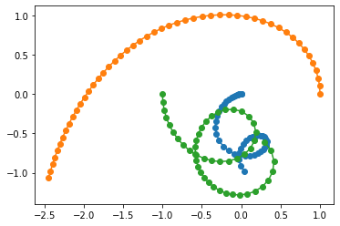

```python
# Definición de las condiciones iniciales
sistema_ejemplo=[
    dict(m=1.0,r=[0.0,0.0,0.0],v=[0.0,0.0,0.0]),
    dict(m=0.2,r=[1.0,0.0,0.0],v=[0.0,1.0,0.0]),
    dict(m=0.5,r=[-1.0,0.0,0.0],v=[0.0,-1.0,0.0]),
]
N,mus,Yo=sistema_a_Y(sistema_ejemplo)

#Tiempo de integración
import numpy as np
Nt=50
ts=np.linspace(0.0,5,Nt,endpoint=True)

# Solución al sistema de ecuaciones diferenciales
from scipy.integrate import odeint
solucion_ejemplo=odeint(eom_ncuerpos,Yo,ts,args=(N,mus))
rs,vs=solucion_a_estado(solucion_ejemplo,N,Nt)

# Componente gráfica del algoritmo
import matplotlib.pyplot as plt
fig=plt.figure()
ax=fig.gca()

for i in range(N):
    ax.plot(rs[i,:,0],rs[i,:,1],marker='o');

ax.set_aspect('equal','box')
```

**Figura 1.3.**

Puede encontrar una versión animada o interactiva de este gráfico en Figuras interactivas y animaciones.

Dado que en general, el movimiento de los cuerpos en un sistema de muchas partículas, ocurre en el espacio de tres dimensiones, la componente gráfica del algortimo anterior puede reemplazarse con este código:

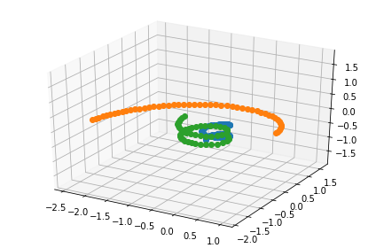

```python
#Componente gráfica del algoritmo
from pymcel.plot import fija_ejes3d_proporcionales
from mpl_toolkits.mplot3d import Axes3D

fig=plt.figure()
ax=fig.gca(projection='3d')

for i in range(N):
    ax.plot(rs[i,:,0],rs[i,:,1],marker='o');

fija_ejes3d_proporcionales(ax)
fig.tight_layout()
```

**Figura 1.4.**

### 1.1.4. Figuras interactivas

#### 1.1.4.1. El problema de los N cuerpos interactivo

> **ADVERTENCIA:** Las figuras interactivas solo funcionan en los *notebooks* de clase.

#### 1.1.4.2. Animación del problema de los N cuerpos

Por su parte para crear una versión animada del sistema que estamos considerando, debemos primero crear una rutina que permita representar la posición del sistema en un tiempo individual.

Ahora debemos mostrar la posición en el tiempo inicial:

```python
%%capture
# Definición de las condiciones iniciales
sistema_ejemplo=[
    dict(m=1.0,r=[0.0,0.0,0.0],v=[0.0,0.0,0.0]),
    dict(m=0.2,r=[1.0,0.0,0.0],v=[0.0,1.0,0.0]),
    dict(m=0.5,r=[-1.0,0.0,0.0],v=[0.0,-1.0,0.0]),
]
N,mus,Yo=sistema_a_Y(sistema_ejemplo)

#Tiempo de integración
import numpy as np
Nt=50
ts=np.linspace(0.0,10.0,Nt,endpoint=True)

# Solución al sistema de ecuaciones diferenciales
from scipy.integrate import odeint
solucion_ejemplo=odeint(eom_ncuerpos,Yo,ts,args=(N,mus))
rs,vs=solucion_a_estado(solucion_ejemplo,N,Nt)

# Componente gráfica del algoritmo
import matplotlib.pyplot as plt
fig=plt.figure()
ax=fig.gca()

puntos=[]
lineas=[]
for i in range(N):
    punto,=ax.plot(rs[i,0,0],rs[i,0,1],marker='o',lw=0);
    linea,=ax.plot(rs[i,0,0],rs[i,0,1],marker=None,lw=1,color='k');
    puntos+=[punto]
    lineas+=[linea]

titulo=ax.set_title(f"t = {ts[0]}")
vmax=abs(rs).max()
ax.set_ylim((-vmax,vmax))
ax.set_xlim((-vmax,vmax))
ax.grid()

# Animación
from matplotlib import animation
def animacion(it):
    for i in range(N):
        puntos[i].set_data(rs[i,it,0],rs[i,it,1])
        lineas[i].set_data(rs[i,:it,0],rs[i,:it,1])
    titulo.set_text(f"t = {ts[it]:.2f}")
    return puntos,lineas

anim=animation.FuncAnimation(fig,animacion,frames=Nt,interval=50,blit=True,repeat=False)
```

[figure not shown]